# PMRC Protocol for Plot-based Measurements of Biodiversity and Growth in Sugarbushes

Ainsley Redd, Emma Griffith, Garrett Simon, Sophie Williams, Teaghan McAllister, Tim Rademacher & Walt Regan-Loomis

2025-11-06

## Introduction

Maple sugaring requires maples trees, which are generally part of a forested stand. These stands are assumed to vary substantially in the structure and composition. However, there is little empirical evidence that helps us understanding the observed variability and its drivers. The following protocol is an attempt to characterize biodiversity, forest composition, and structure at the sugarbush level. We started using this protocol at the Proctor Maple Research Center in the summer of 2025.

## Methods: Data collection

Forest composition was sampled throughout the PMRC land parcel through the selection of survey plots that provide a representative sample of the local ecosystem and terrain diversity. Plots were designed using a method resembling that set forth in the USDA Forest Inventory and Analysis (FIA) plot design[^1]. See Figure 1 for a visual reference.

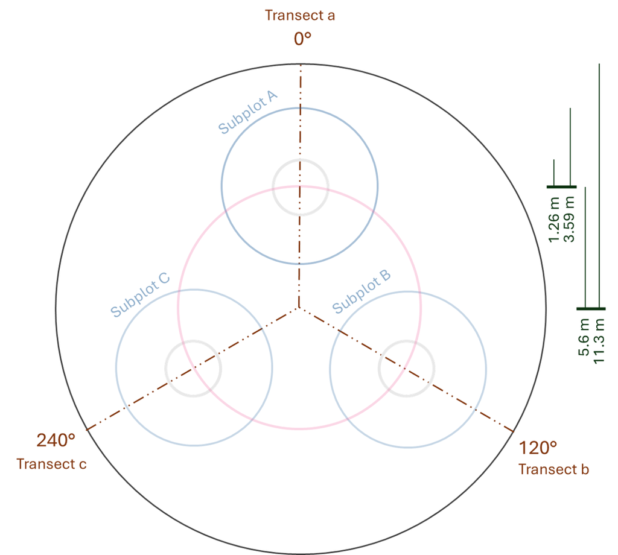

The 11.3-meter-radius plot is divided into 3 transect lines at 120 degree increments. Each transect line possesses a 3.59-meter-radius subplot, centered at 5.6 meters from the plot center.

Some data points were collected only on features residing within one of the 3 subplots or along the 3 transects, while others were measured throughout the entirety of the plot area. Measurements of trees, maple sap tubing, wildlife tracks, and tree-related microhabitats occurred throughout the entire plot. Understory composition, bryophytes, and coarse woody debris were primarily measured along the transect lines. Macrofungi measurements occurred within the 3 subplots.

To mark the plots, the measurement team traveled to the plot center using a set of coordinates. With a PVC pipe posted at plot center, one individual stood at plot center with a compass and either a laser range finder or measuring tape in metric units. That individual directed another individual (holding the other end of the measuring tape, if used) to the 11.3-m plot boundary and the 5.6-m subplot centers for marking via flags. The 3.59-meter subplot boundary radius about the subplot center was then flagged in similar fashion.

Ideally, prior to any other individuals moving onto and potentially disturbing the plot, the team conducts fauna and fungi measurements. Fungi should at a minimum be identified and flagged before the remaining team travels onto the plot by foot, saved for later analysis.

After doing so, the measurement team splits into three primary groups: trees, understory & bryophytes, and fungi. For tree measurements, one individual remains at plot center and directs another individual towards relevant trees within the plot area in a clockwise direction, starting at magnetic north. Trees greater than 9cm DBH (1.3 meters above ground), either alive or dead, excluding snags, should be included. The moving individual should identify the DBH of the tree, species, canopy status, and crown dieback, as well as label the tree with flagging tape. The individual at plot center should call out the magnetic angle and distance in meters to the tree, before sketching the tree location on a printed plot diagram (resembling Figure 1). Ideally, a third individual on the tree group records the measurements. After completing all trees, it is recommended that a member of the trees team uses the laser range finder to identify the height of all the flagged trees, if possible. This requires a substantial amount of movement around each tree to get the highest possible line-of-sight for an accurate height reading.

After labeling all relevant trees, the tree team should transition to taphole measurements for all labeled trees, as applicable, and coarse woody debris measurements along the 3 transects. Each task can require either one or two individuals. For tapholes, one should use digital calipers to measure the depth, width, and height of all tapholes in millimeters. For coarse woody debris, ideally two individuals measure the length (meters), diameter (cm), decomposition class (qualitative 1-5 judgement), and species (if possible) for any fallen debris touching the transect lines that is longer than 2 meters in length and 7 cm in diameter.

## Results

### Vegetation structure

As shown in Figure 2 below, the plots predominately contain sugar maple, with sizable fractions of American beech and yellow birch. Approximately half of the sampled sugar maple population possessed visible tapholes from recent sugaring operations.

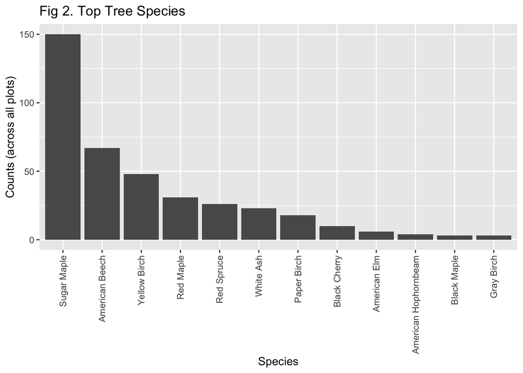

```r
source("01_read_data.R")
require ("ggplot2")
require ("forcats")
hist_counts <- as.data.frame(table(d_tree$spp))
hist_counts <- hist_counts[order(-hist_counts$Freq),]
rownames(hist_counts) <- NULL
ggplot(head(hist_counts, 12), aes(x = reorder(Var1, -Freq), y=Freq)) + geom_bar(stat="identity") + labs(title="Fig 2. Top Tree Species", x="Species", y="Counts (across all plots)") + theme(axis.text.x = element_text(angle = 90, vjust = 0.5, hjust=1))
```

```r
source("01_read_data.R")

### Use external script to calculate total basal area surrounding our trees.
## This script depends on the `d_tree` dataframe created by "01_read_data.R"
## Primary output is the `d_tree_competition` dataframe.
#source("02_calculate_basal_area_buffer.R")

# Plot the results.
#plot(d_tree_competition$dbh, d_tree_competition$compensated_buffer_area, xlab="DBH, cm", ylab="Basal area (sq. m) within 5m radius of tree", main="Fig. 3: PMRC Tree Competitiveness")
```

#### Tree growth

#### Coarse Woody Debris

Plots varied in their density of coarse woody debris (CWD). A significant number of plot transects did not contain any qualifying CWD. Due to decomposition, over two-thirds of recorded CWD could only be classified as a hardwood or unknown species. Some newly-fallen debris possessed enough bark characteristics for confident classification.

### Vegetation composition

### Tree-related Microhabitats (TreMs)

### Understory composition

#### Bryophytes

### Macrofungi

### Tubing

### Wildlife

## To sugar or not to sugar

[^1]: Bechtold, William, A.; Scott, Charles T. 2005. The forest inventory and analysis plot design. Gen. Tech. Rep. SRS-80. Asheville, NC: U.S. Department of Agriculture, Forest Service, Southern Research Station, p. 37-52